# Walmart Sales Analysis and Forcast

*Please note that I have **only used the "train" dataset without the "test" one** due to the non-existance of target variable so that it can be submitted to Kaggle competetion and checked for correctness. Unfortunately, I'm not in this competetion and thus cannot check my solution. This Jupyter Notebook has nothing to do with the competetion. Therefore, I have only used the train dataset and tried to handle the shortage of samples.*

## Outline

- Import
- Data Main Aspects
- Preprocessing
- EDA
- Feature Selection
- EDA - Extention
- Dimensionality Reduction
- Modeling
- Quality Metric Summary

```python
import numpy as np, pandas as pd, scipy as sp;
import seaborn as sns, matplotlib.pyplot as plt;
from matplotlib.lines import Line2D

plt.rcParams["figure.figsize"] = (12, 8)
plt.rcParams['font.size'] = 13.0
plt.rcParams.update({'legend.fontsize': 14, 'legend.handlelength': 2})

pd.options.mode.chained_assignment = None
sns.set_style("whitegrid")


from sklearn.model_selection import train_test_split, TimeSeriesSplit, GridSearchCV
from sklearn.preprocessing import  StandardScaler, MinMaxScaler
from sklearn.pipeline import Pipeline

from sklearn.dummy import DummyRegressor
from lightgbm import LGBMRegressor
from sklearn.ensemble import RandomForestRegressor, VotingRegressor
from sklearn.neighbors import KNeighborsRegressor

import math
from sklearn.metrics import mean_absolute_error, r2_score
from sklearn.decomposition import PCA
import umap
```

# Import

```python
features = pd.read_csv("./data/features.csv")
stores = pd.read_csv("./data/stores.csv")
train = pd.read_csv("./data/train.csv")
test = pd.read_csv("./data/test.csv")
```

# View data main aspects

Features Dataset

```python
print("  Shape:", str(features.shape), "\n",
      " Number of cells:", features.shape[0] * features.shape[1], "\n",
      " Missing cells:", np.sum(np.sum(features.isna())), "\n"
      "  in columns: \n" + str(np.sum(features.isna())))
features.head()
```

```
  Shape: (8190, 12)
  Number of cells: 98280
  Missing cells: 24040
  in columns:
Store              0
Date               0
Temperature        0
Fuel_Price         0
MarkDown1       4158
MarkDown2       5269
MarkDown3       4577
MarkDown4       4726
MarkDown5       4140
CPI              585
Unemployment     585
IsHoliday          0
dtype: int64
```

|  | Store | Date | Temperature | Fuel_Price | MarkDown1 | MarkDown2 | MarkDown3 | MarkDown4 | MarkDown5 | CPI | Unemployment | IsHoliday |
| --- | --- | --- | --- | --- | --- | --- | --- | --- | --- | --- | --- | --- |
| 0 | 1 | 2010-02-05 | 42.31 | 2.572 | NaN | NaN | NaN | NaN | NaN | 211.096358 | 8.106 | False |
| 1 | 1 | 2010-02-12 | 38.51 | 2.548 | NaN | NaN | NaN | NaN | NaN | 211.242170 | 8.106 | True |
| 2 | 1 | 2010-02-19 | 39.93 | 2.514 | NaN | NaN | NaN | NaN | NaN | 211.289143 | 8.106 | False |
| 3 | 1 | 2010-02-26 | 46.63 | 2.561 | NaN | NaN | NaN | NaN | NaN | 211.319643 | 8.106 | False |
| 4 | 1 | 2010-03-05 | 46.50 | 2.625 | NaN | NaN | NaN | NaN | NaN | 211.350143 | 8.106 | False |

```python
mask = (features['MarkDown1'].isna() |
        features['MarkDown2'].isna() |
        features['MarkDown3'].isna() |
        features['MarkDown4'].isna() |
        features['MarkDown5'].isna())
print("Stores that are missing any Markdowns:", features[mask].Store.unique().size, "... All Stores")
```

```
Stores that are missing any Markdowns: 45 ... All Stores
```

```python
print("Weeks that are missing MarkDown1 in all stores:", features[features['MarkDown1'].isna()]['Date'].unique().size)
print("Weeks that are missing MarkDown2 in all stores:", features[features['MarkDown2'].isna()]['Date'].unique().size)
print("Weeks that are missing MarkDown3 in all stores:", features[features['MarkDown3'].isna()]['Date'].unique().size)
print("Weeks that are missing MarkDown4 in all stores:", features[features['MarkDown4'].isna()]['Date'].unique().size)
print("Weeks that are missing MarkDown5 in all stores:", features[features['MarkDown5'].isna()]['Date'].unique().size)
DATE_SET = set(features[features['MarkDown1'].isna()]['Date'].tolist() +
               features[features['MarkDown2'].isna()]['Date'].tolist() +
              features[features['MarkDown3'].isna()]['Date'].tolist() +
              features[features['MarkDown4'].isna()]['Date'].tolist() +
              features[features['MarkDown5'].isna()]['Date'].tolist())
print("All dates in all stores that are missing any markdowns:", len(DATE_SET), "out of", len(set(features['Date'].tolist())))

all_dates = features[mask]
all_dates
```

```
Weeks that are missing MarkDown1 in all stores: 107
Weeks that are missing MarkDown2 in all stores: 160
Weeks that are missing MarkDown3 in all stores: 175
Weeks that are missing MarkDown4 in all stores: 181
Weeks that are missing MarkDown5 in all stores: 92
All dates in all stores that are missing any markdowns: 182 out of 182
```

|  | Store | Date | Temperature | Fuel_Price | MarkDown1 | MarkDown2 | MarkDown3 | MarkDown4 | MarkDown5 | CPI | Unemployment | IsHoliday |
| --- | --- | --- | --- | --- | --- | --- | --- | --- | --- | --- | --- | --- |
| 0 | 1 | 2010-02-05 | 42.31 | 2.572 | NaN | NaN | NaN | NaN | NaN | 211.096358 | 8.106 | False |
| 1 | 1 | 2010-02-12 | 38.51 | 2.548 | NaN | NaN | NaN | NaN | NaN | 211.242170 | 8.106 | True |
| 2 | 1 | 2010-02-19 | 39.93 | 2.514 | NaN | NaN | NaN | NaN | NaN | 211.289143 | 8.106 | False |
| 3 | 1 | 2010-02-26 | 46.63 | 2.561 | NaN | NaN | NaN | NaN | NaN | 211.319643 | 8.106 | False |
| 4 | 1 | 2010-03-05 | 46.50 | 2.625 | NaN | NaN | NaN | NaN | NaN | 211.350143 | 8.106 | False |
| ... | ... | ... | ... | ... | ... | ... | ... | ... | ... | ... | ... | ... |
| 8158 | 45 | 2012-12-21 | 43.54 | 3.577 | 4187.83 | NaN | 238.00 | 92.68 | 2977.33 | 192.458906 | 8.667 | False |
| 8170 | 45 | 2013-03-15 | 42.81 | 3.834 | 9867.03 | NaN | 11.08 | 912.87 | 1360.36 | 193.296277 | 8.625 | False |
| 8171 | 45 | 2013-03-22 | 36.55 | 3.800 | 11923.74 | NaN | 308.00 | 1764.47 | 1647.31 | 193.369533 | 8.625 | False |
| 8172 | 45 | 2013-03-29 | 40.68 | 3.784 | 5444.00 | NaN | 350.84 | 53.90 | 1722.11 | 193.442790 | 8.625 | False |
| 8176 | 45 | 2013-04-26 | 50.64 | 3.615 | 1260.65 | NaN | 57.52 | 40.51 | 2476.18 | 193.589304 | 8.335 | False |

5670 rows × 12 columns

Stores Dataset

```python
print("  Shape:", str(stores.shape), "\n",
      " Number of cells:", stores.shape[0] * stores.shape[1], "\n",
      " Missing cells:", np.sum(np.sum(stores.isna())), "\n"
      "  in columns: \n" + str(np.sum(stores.isna())))
stores.head()
```

```
  Shape: (45, 3)
  Number of cells: 135
  Missing cells: 0
  in columns:
Store    0
Type     0
Size     0
dtype: int64
```

|  | Store | Type | Size |
| --- | --- | --- | --- |
| 0 | 1 | A | 151315 |
| 1 | 2 | A | 202307 |
| 2 | 3 | B | 37392 |
| 3 | 4 | A | 205863 |
| 4 | 5 | B | 34875 |

Train Dataset

```python
print("  Shape:", str(train.shape), "\n",
      " Number of cells:", train.shape[0] * train.shape[1], "\n",
      " Missing cells:", np.sum(np.sum(train.isna())), "\n"
      "  in columns: \n" + str(np.sum(train.isna())))
train.head()
```

```
  Shape: (421570, 5)
  Number of cells: 2107850
  Missing cells: 0
  in columns:
Store           0
Dept            0
Date            0
Weekly_Sales    0
IsHoliday       0
dtype: int64
```

|  | Store | Dept | Date | Weekly_Sales | IsHoliday |
| --- | --- | --- | --- | --- | --- |
| 0 | 1 | 1 | 2010-02-05 | 24924.50 | False |
| 1 | 1 | 1 | 2010-02-12 | 46039.49 | True |
| 2 | 1 | 1 | 2010-02-19 | 41595.55 | False |
| 3 | 1 | 1 | 2010-02-26 | 19403.54 | False |
| 4 | 1 | 1 | 2010-03-05 | 21827.90 | False |

```python
print("  Shape:", str(test.shape), "\n",
      " Number of cells:", test.shape[0] * test.shape[1], "\n",
      " Missing cells:", np.sum(np.sum(test.isna())), "\n"
      "  in columns: \n" + str(np.sum(test.isna())))
test.head()
```

```
  Shape: (115064, 4)
  Number of cells: 460256
  Missing cells: 0
  in columns:
Store        0
Dept         0
Date         0
IsHoliday    0
dtype: int64
```

|  | Store | Dept | Date | IsHoliday |
| --- | --- | --- | --- | --- |
| 0 | 1 | 1 | 2012-11-02 | False |
| 1 | 1 | 1 | 2012-11-09 | False |
| 2 | 1 | 1 | 2012-11-16 | False |
| 3 | 1 | 1 | 2012-11-23 | True |
| 4 | 1 | 1 | 2012-11-30 | False |

# Pre-Processing

```python
print("Train Shape", train.shape, "Nan:", np.sum(np.sum(train.isna())))
print("Features Shape", features.shape, "Nan:", np.sum(np.sum(features.isna())))
print("Stores Shape", stores.shape, "Nan:", np.sum(np.sum(stores.isna())))
```

```
Train Shape (421570, 5) Nan: 0
Features Shape (8190, 12) Nan: 24040
Stores Shape (45, 3) Nan: 0
```

### Note:

Note that we will lose 585 rows in the features dataset due to the non-existance of their corresponding department number, type, and size which in this case meaningless for our hypothesis

```python
train_stores = pd.merge(train, stores, how='inner', on='Store')
df = pd.merge(train_stores, features, how='inner', on=['Store', 'Date', 'IsHoliday'])
print("DF Shape", df.shape, "Nan:", np.sum(np.sum(df.isna())))

df.head()
```

```
DF Shape (421570, 16) Nan: 1422431
```

|  | Store | Dept | Date | Weekly_Sales | IsHoliday | Type | Size | Temperature | Fuel_Price | MarkDown1 | MarkDown2 | MarkDown3 | MarkDown4 | MarkDown5 | CPI | Unemployment |
| --- | --- | --- | --- | --- | --- | --- | --- | --- | --- | --- | --- | --- | --- | --- | --- | --- |
| 0 | 1 | 1 | 2010-02-05 | 24924.50 | False | A | 151315 | 42.31 | 2.572 | NaN | NaN | NaN | NaN | NaN | 211.096358 | 8.106 |
| 1 | 1 | 2 | 2010-02-05 | 50605.27 | False | A | 151315 | 42.31 | 2.572 | NaN | NaN | NaN | NaN | NaN | 211.096358 | 8.106 |
| 2 | 1 | 3 | 2010-02-05 | 13740.12 | False | A | 151315 | 42.31 | 2.572 | NaN | NaN | NaN | NaN | NaN | 211.096358 | 8.106 |
| 3 | 1 | 4 | 2010-02-05 | 39954.04 | False | A | 151315 | 42.31 | 2.572 | NaN | NaN | NaN | NaN | NaN | 211.096358 | 8.106 |
| 4 | 1 | 5 | 2010-02-05 | 32229.38 | False | A | 151315 | 42.31 | 2.572 | NaN | NaN | NaN | NaN | NaN | 211.096358 | 8.106 |

### Processing Date Var

```python
print("Date variable type:", df['Date'].dtype)
```

```
Date variable type: object
```

```python
if('Date' in df.columns):
    df['Year'] = pd.DatetimeIndex(df['Date']).year
    df['Month'] = pd.DatetimeIndex(df['Date']).month
    df['Day'] = pd.DatetimeIndex(df['Date']).day
    df['Date'] = pd.to_datetime(df['Date'])
#     del df['Date']
```

```python
df = df.sort_values(by=['Year', 'Month', 'Day'])
df.head()
```

|  | Store | Dept | Date | Weekly_Sales | IsHoliday | Type | Size | Temperature | Fuel_Price | MarkDown1 | MarkDown2 | MarkDown3 | MarkDown4 | MarkDown5 | CPI | Unemployment | Year | Month | Day |
| --- | --- | --- | --- | --- | --- | --- | --- | --- | --- | --- | --- | --- | --- | --- | --- | --- | --- | --- | --- |
| 0 | 1 | 1 | 2010-02-05 | 24924.50 | False | A | 151315 | 42.31 | 2.572 | NaN | NaN | NaN | NaN | NaN | 211.096358 | 8.106 | 2010 | 2 | 5 |
| 1 | 1 | 2 | 2010-02-05 | 50605.27 | False | A | 151315 | 42.31 | 2.572 | NaN | NaN | NaN | NaN | NaN | 211.096358 | 8.106 | 2010 | 2 | 5 |
| 2 | 1 | 3 | 2010-02-05 | 13740.12 | False | A | 151315 | 42.31 | 2.572 | NaN | NaN | NaN | NaN | NaN | 211.096358 | 8.106 | 2010 | 2 | 5 |
| 3 | 1 | 4 | 2010-02-05 | 39954.04 | False | A | 151315 | 42.31 | 2.572 | NaN | NaN | NaN | NaN | NaN | 211.096358 | 8.106 | 2010 | 2 | 5 |
| 4 | 1 | 5 | 2010-02-05 | 32229.38 | False | A | 151315 | 42.31 | 2.572 | NaN | NaN | NaN | NaN | NaN | 211.096358 | 8.106 | 2010 | 2 | 5 |

### Processing Categorical variables

```python
df = pd.get_dummies(df, columns=['Type'])
df['IsHoliday'] = np.where(df['IsHoliday'] == True, 1, 0)
df
```

|  | Store | Dept | Date | Weekly_Sales | IsHoliday | Size | Temperature | Fuel_Price | MarkDown1 | MarkDown2 | ... | MarkDown4 | MarkDown5 | CPI | Unemployment | Year | Month | Day | Type_A | Type_B | Type_C |
| --- | --- | --- | --- | --- | --- | --- | --- | --- | --- | --- | --- | --- | --- | --- | --- | --- | --- | --- | --- | --- | --- |
| 0 | 1 | 1 | 2010-02-05 | 24924.50 | 0 | 151315 | 42.31 | 2.572 | NaN | NaN | ... | NaN | NaN | 211.096358 | 8.106 | 2010 | 2 | 5 | 1 | 0 | 0 |
| 1 | 1 | 2 | 2010-02-05 | 50605.27 | 0 | 151315 | 42.31 | 2.572 | NaN | NaN | ... | NaN | NaN | 211.096358 | 8.106 | 2010 | 2 | 5 | 1 | 0 | 0 |
| 2 | 1 | 3 | 2010-02-05 | 13740.12 | 0 | 151315 | 42.31 | 2.572 | NaN | NaN | ... | NaN | NaN | 211.096358 | 8.106 | 2010 | 2 | 5 | 1 | 0 | 0 |
| 3 | 1 | 4 | 2010-02-05 | 39954.04 | 0 | 151315 | 42.31 | 2.572 | NaN | NaN | ... | NaN | NaN | 211.096358 | 8.106 | 2010 | 2 | 5 | 1 | 0 | 0 |
| 4 | 1 | 5 | 2010-02-05 | 32229.38 | 0 | 151315 | 42.31 | 2.572 | NaN | NaN | ... | NaN | NaN | 211.096358 | 8.106 | 2010 | 2 | 5 | 1 | 0 | 0 |
| ... | ... | ... | ... | ... | ... | ... | ... | ... | ... | ... | ... | ... | ... | ... | ... | ... | ... | ... | ... | ... | ... |
| 421565 | 45 | 93 | 2012-10-26 | 2487.80 | 0 | 118221 | 58.85 | 3.882 | 4018.91 | 58.08 | ... | 211.94 | 858.33 | 192.308899 | 8.667 | 2012 | 10 | 26 | 0 | 1 | 0 |
| 421566 | 45 | 94 | 2012-10-26 | 5203.31 | 0 | 118221 | 58.85 | 3.882 | 4018.91 | 58.08 | ... | 211.94 | 858.33 | 192.308899 | 8.667 | 2012 | 10 | 26 | 0 | 1 | 0 |
| 421567 | 45 | 95 | 2012-10-26 | 56017.47 | 0 | 118221 | 58.85 | 3.882 | 4018.91 | 58.08 | ... | 211.94 | 858.33 | 192.308899 | 8.667 | 2012 | 10 | 26 | 0 | 1 | 0 |
| 421568 | 45 | 97 | 2012-10-26 | 6817.48 | 0 | 118221 | 58.85 | 3.882 | 4018.91 | 58.08 | ... | 211.94 | 858.33 | 192.308899 | 8.667 | 2012 | 10 | 26 | 0 | 1 | 0 |
| 421569 | 45 | 98 | 2012-10-26 | 1076.80 | 0 | 118221 | 58.85 | 3.882 | 4018.91 | 58.08 | ... | 211.94 | 858.33 | 192.308899 | 8.667 | 2012 | 10 | 26 | 0 | 1 | 0 |

421570 rows × 21 columns

### Split

Let's be quick and split the data before we get any insight, change anything that we couldn't have changed if we didn't look at the test data, it's a good practice too if the DataViz part is done after as you might get thoughts of modeling technqiue based on the test data added (Do that only if you have very short amount of data)

# ————————————————————————

### Important Note

This type of split is to simulate a real life example, the idea is to split **Temporally-Based** even though we're not going to be able to test the 11th, and 12th month, this is a bad split if only we had more data to teach the model at least twice on these missing months in the test set.

We will split the values in order of their dates as if we are validating on the present, training on the past, and testing on the future

# ————————————————————————

```python
X = df.drop(['Weekly_Sales'], axis=1)
y = df['Weekly_Sales']
X_train, X_test, y_train, y_test = train_test_split(X, y, test_size=0.3, shuffle=False)

print("Train:", X_train.shape, y_train.shape,
      "Test:", X_test.shape, y_test.shape)

df_eda = pd.concat([X_train, y_train], axis=1 )
print('DF for EDA:', df_eda.shape)
```

```
Train: (295099, 20) (295099,) Test: (126471, 20) (126471,)
DF for EDA: (295099, 21)
```

```python
print("X_train:", str(X_train.Date.min())[:10], "→", str(X_train.Date.max())[:10])
print("X_test:", str(X_test.Date.min())[:10], "→", str(X_test.Date.max())[:10])
```

```
X_train: 2010-02-05 → 2012-01-06
X_test: 2012-01-06 → 2012-10-26
```

### Filling the NaNs

We can go with either a **fixed value as 0**, **statistical value as the mean or mode**, **algorithmic values as KNN or MICE**

In this case, 0 gives the intuition to the algorithm the nearly 5000 Dept. (More than half) has not done any marketing campains which is completely false and misleading!

An algorithmic value is a good choice but the problem is that about 60% of the data are missing, this gives us the idea that there might be more missing data in the future and applying an algorithm at that time will make the model suffer.

Best and a "good enough effectiveness" can be gotten from applying the mean and giving a fair advantage of the lost cells. This is done after splitting the data so that we don't introduce any data leakages (distributional leakages). **We will have to store the mean**

```python
df_eda[['MarkDown1','MarkDown2','MarkDown3','MarkDown4','MarkDown5']] =\
df_eda[['MarkDown1','MarkDown2','MarkDown3','MarkDown4','MarkDown5']].fillna(\
df_eda[['MarkDown1','MarkDown2','MarkDown3','MarkDown4','MarkDown5']].mean())

print(df_eda[['MarkDown1','MarkDown2','MarkDown3','MarkDown4','MarkDown5']].mean())
print("NaNs in Dataset:", np.sum(np.sum(df_eda.isna())))
df_eda.head()
```

```
MarkDown1    4585.925206
MarkDown2    8682.600841
MarkDown3    7933.275520
MarkDown4    1512.727211
MarkDown5    6400.281882
dtype: float64
NaNs in Dataset: 0
```

|  | Store | Dept | Date | IsHoliday | Size | Temperature | Fuel_Price | MarkDown1 | MarkDown2 | MarkDown3 | ... | MarkDown5 | CPI | Unemployment | Year | Month | Day | Type_A | Type_B | Type_C | Weekly_Sales |
| --- | --- | --- | --- | --- | --- | --- | --- | --- | --- | --- | --- | --- | --- | --- | --- | --- | --- | --- | --- | --- | --- |
| 0 | 1 | 1 | 2010-02-05 | 0 | 151315 | 42.31 | 2.572 | 4585.925206 | 8682.600841 | 7933.27552 | ... | 6400.281882 | 211.096358 | 8.106 | 2010 | 2 | 5 | 1 | 0 | 0 | 24924.50 |
| 1 | 1 | 2 | 2010-02-05 | 0 | 151315 | 42.31 | 2.572 | 4585.925206 | 8682.600841 | 7933.27552 | ... | 6400.281882 | 211.096358 | 8.106 | 2010 | 2 | 5 | 1 | 0 | 0 | 50605.27 |
| 2 | 1 | 3 | 2010-02-05 | 0 | 151315 | 42.31 | 2.572 | 4585.925206 | 8682.600841 | 7933.27552 | ... | 6400.281882 | 211.096358 | 8.106 | 2010 | 2 | 5 | 1 | 0 | 0 | 13740.12 |
| 3 | 1 | 4 | 2010-02-05 | 0 | 151315 | 42.31 | 2.572 | 4585.925206 | 8682.600841 | 7933.27552 | ... | 6400.281882 | 211.096358 | 8.106 | 2010 | 2 | 5 | 1 | 0 | 0 | 39954.04 |
| 4 | 1 | 5 | 2010-02-05 | 0 | 151315 | 42.31 | 2.572 | 4585.925206 | 8682.600841 | 7933.27552 | ... | 6400.281882 | 211.096358 | 8.106 | 2010 | 2 | 5 | 1 | 0 | 0 | 32229.38 |

5 rows × 21 columns

# EDA

### For 2010-02-05 → 2012-01-06 *(Training)*

### Descriptive Stat.

```python
df_eda.describe()
```

|  | Store | Dept | IsHoliday | Size | Temperature | Fuel_Price | MarkDown1 | MarkDown2 | MarkDown3 | MarkDown4 | MarkDown5 | CPI | Unemployment | Year | Month | Day | Type_A | Type_B | Type_C | Weekly_Sales |
| --- | --- | --- | --- | --- | --- | --- | --- | --- | --- | --- | --- | --- | --- | --- | --- | --- | --- | --- | --- | --- |
| count | 295099.000000 | 295099.000000 | 295099.000000 | 295099.000000 | 295099.000000 | 295099.000000 | 295099.000000 | 295099.000000 | 295099.000000 | 295099.000000 | 295099.000000 | 295099.000000 | 295099.000000 | 295099.000000 | 295099.000000 | 295099.000000 | 295099.000000 | 295099.000000 | 295099.000000 | 295099.000000 |
| mean | 22.131996 | 44.180716 | 0.080292 | 136928.534139 | 58.863853 | 3.209685 | 4585.925206 | 8682.600841 | 7933.275520 | 1512.727211 | 6400.281882 | 169.598926 | 8.228570 | 2010.526559 | 6.838319 | 15.568796 | 0.512143 | 0.388029 | 0.099828 | 16108.860798 |
| std | 12.788940 | 30.426934 | 0.271745 | 60922.948072 | 18.928325 | 0.438421 | 1496.027136 | 4962.202432 | 6232.167312 | 574.733810 | 2060.557274 | 38.490040 | 1.866028 | 0.505815 | 3.338034 | 8.787723 | 0.499853 | 0.487302 | 0.299770 | 22968.068908 |
| min | 1.000000 | 1.000000 | 0.000000 | 34875.000000 | -2.060000 | 2.472000 | 0.500000 | 0.000000 | -0.870000 | 2.000000 | 135.160000 | 126.064000 | 4.420000 | 2010.000000 | 1.000000 | 1.000000 | 0.000000 | 0.000000 | 0.000000 | -4988.940000 |
| 25% | 11.000000 | 18.000000 | 0.000000 | 93638.000000 | 45.260000 | 2.808000 | 4585.925206 | 8682.600841 | 7933.275520 | 1512.727211 | 6400.281882 | 131.901968 | 7.274000 | 2010.000000 | 4.000000 | 8.000000 | 0.000000 | 0.000000 | 0.000000 | 2146.660000 |
| 50% | 22.000000 | 37.000000 | 0.000000 | 140167.000000 | 60.280000 | 3.129000 | 4585.925206 | 8682.600841 | 7933.275520 | 1512.727211 | 6400.281882 | 182.162844 | 8.028000 | 2011.000000 | 7.000000 | 16.000000 | 1.000000 | 0.000000 | 0.000000 | 7726.650000 |
| 75% | 33.000000 | 72.000000 | 0.000000 | 202505.000000 | 73.260000 | 3.594000 | 4585.925206 | 8682.600841 | 7933.275520 | 1512.727211 | 6400.281882 | 211.109654 | 8.684000 | 2011.000000 | 10.000000 | 23.000000 | 1.000000 | 1.000000 | 0.000000 | 20357.580000 |
| max | 45.000000 | 99.000000 | 1.000000 | 219622.000000 | 100.140000 | 4.211000 | 34348.140000 | 104519.540000 | 141630.610000 | 20834.370000 | 37581.270000 | 223.433241 | 14.313000 | 2012.000000 | 12.000000 | 31.000000 | 1.000000 | 1.000000 | 1.000000 | 693099.360000 |

### Note

- Weekly monthly sales can be lower than Zero, that might be an indicator of a net loss due to exceeding the break even point
- We can see some features that are having a strongly high std., this might need scaling if the spread of data is not meaningfull when compared to other features

### Box Plot

Figure has been zoomed from 700,000 to 230,000 due to **weekly sales** value being too high as it reaches ~700,000 alone. (No other features data point has been lost) We can surely split this data into size, weekly sales, and all others as thier distributions are very different and it affects the visual, but we will have more analysis later so no need for that now

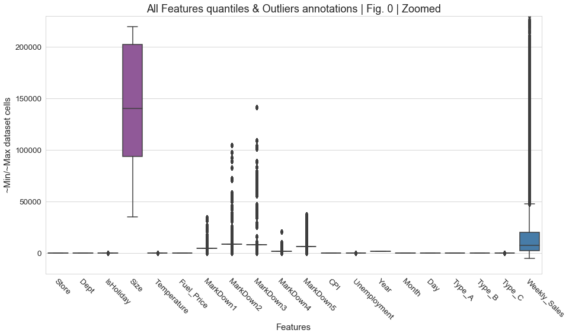

```python
fig, ax = plt.subplots(figsize=(15,8))
ax = sns.boxplot(x="variable", y="value", data=pd.melt(df_eda.drop('Date', inplace=False, axis=1)), palette='Set1')

ax.axes.set_title("All Features quantiles & Outliers annotations | Fig. 0 | Zoomed",fontsize=18)
ax.set_xlabel("Features",fontsize=15)
ax.set_ylabel("~Min/~Max dataset cells",fontsize=15)
ax.tick_params(labelsize=13.5)
ax.set(ylim=(-20000, 230000))

plt.setp( ax.xaxis.get_majorticklabels(), rotation=-45, ha="left", rotation_mode="anchor");
```

### Insights

- Size is the only variable that appears to be fairly distributed. Against The strongest varied variable which is the weekly sales
- We can get some insights about all markdowns as it has many outliers but that is an unfair analysis as we have filled 60% of the data with the mean that resides either close or on the median which gives outliers to show up

## Time Series

```python
def makeLineplot(data, groubed_by_x, title,  y_label= 'Weekly Sales',
                 hue_order = ['Weekly_Sales'], fix_ticks_num=True, rotate=True ):
    fig, ax = plt.subplots(figsize=(17,8))
    sns.lineplot(x=groubed_by_x, y='value', hue='variable', data=pd.melt(data, [groubed_by_x]), estimator=None,
                palette = 'Set1', hue_order=hue_order)

    ax.axes.set_title(title,fontsize=18)
    ax.set_xlabel(groubed_by_x,fontsize=15)
    ax.set_ylabel(y_label,fontsize=15)
    ax.tick_params(labelsize=12.5)
    if(fix_ticks_num):
        ax.set_xticks(ticks=data.index.unique().tolist()[2::3], minor=False)
    else:
        ax.set_xticks(ticks=data.index.unique().tolist(), minor=False)

    plt.legend()
    if(rotate):
        plt.setp( ax.xaxis.get_majorticklabels(), rotation=-45, ha="left", rotation_mode="anchor");
```

#### Time Series By Year | It is better to use bar plot as we only have 3 years

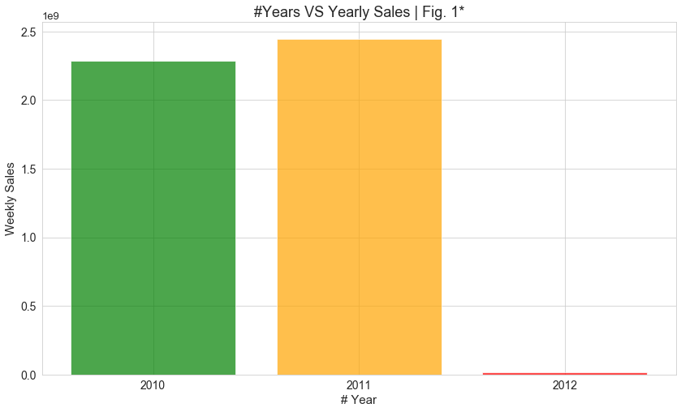

```python
year_sales = df_eda[['Weekly_Sales', 'Year']].groupby('Year').sum()['Weekly_Sales'].tolist()
years = ['2010', '2011', '2012']
fig, ax = plt.subplots(figsize=(14,8))

ax.bar(years,
       year_sales,
       color=['g', 'orange', 'red'], alpha=0.7)

ax.set_title("#Years VS Yearly Sales | Fig. 1*", fontsize=18)
ax.set_xticks(['2010', '2011', '2012'])
ax.set_ylabel("Weekly Sales", fontsize=15)
ax.set_xlabel("# Year", fontsize=15);
ax.tick_params(labelsize=14)
```

#### Validate difference is not due to aubandance

```
Years: [2010, 2011, 2012]
Counts: [140679, 153453, 967]
```

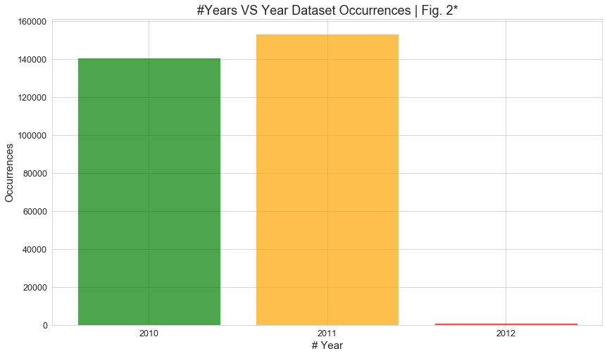

```python
fig, ax = plt.subplots(figsize=(14,8))

unique, counts = np.unique(df_eda['Year'], return_counts=True)
print("Years:", unique.tolist())
print("Counts:", counts.tolist())

ax.bar(unique, counts, color=['g', 'orange', 'red'], alpha=0.7)
ax.set_title("#Years VS Year Dataset Occurrences | Fig. 2*", fontsize=18)
ax.set_xticks(unique.tolist())
ax.set_ylabel("Occurrences", fontsize=15)
ax.set_xlabel("# Year", fontsize=15);
ax.tick_params(labelsize=12.5)
```

#### Note

Now we can tell that it's only due to abundance of class, not real difference. We already now that as this data analysis is being done on a time span that was specified at the start

#### Time Series By Full Date (Weekly)

```
			 ** Ticks only show every 3rd week, but data points are all covered **
```

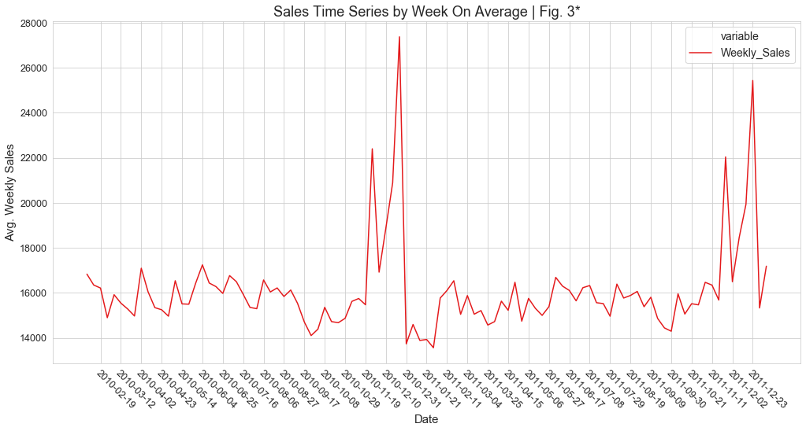

```python
time_series_sales = df_eda[['Date', 'Weekly_Sales']].groupby(by='Date').mean()
time_series_sales['Date'] = time_series_sales.index

makeLineplot(data = time_series_sales, groubed_by_x='Date',
             title="Sales Time Series by Week On Average | Fig. 3*", y_label='Avg. Weekly Sales');

print("\n\t\t\t ** Ticks only show every 3rd week, but data points are all covered **")
```

#### Time Series By Month

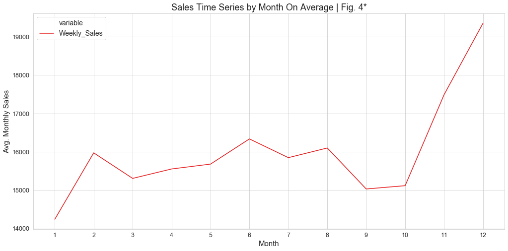

```python
time_series_sales = df_eda[['Month', 'Weekly_Sales']]
time_series_sales = time_series_sales.groupby(by='Month').mean()
time_series_sales['Month'] = time_series_sales.index

makeLineplot(data = time_series_sales, groubed_by_x='Month',
             title="Sales Time Series by Month On Average | Fig. 4*",
             fix_ticks_num=False, rotate=False, y_label="Avg. Monthly Sales");
```

#### Validate that the rises are not caused by the abundance of class

```
Months: [1, 2, 3, 4, 5, 6, 7, 8, 9, 10, 11, 12]
Counts: [12662, 23580, 23601, 29443, 23492, 23384, 29182, 23368, 26485, 26487, 23613, 29802]
This is just to make sure that the rise on the 12th month is not caused by the abundance of the class, as they all values are pretty close
```

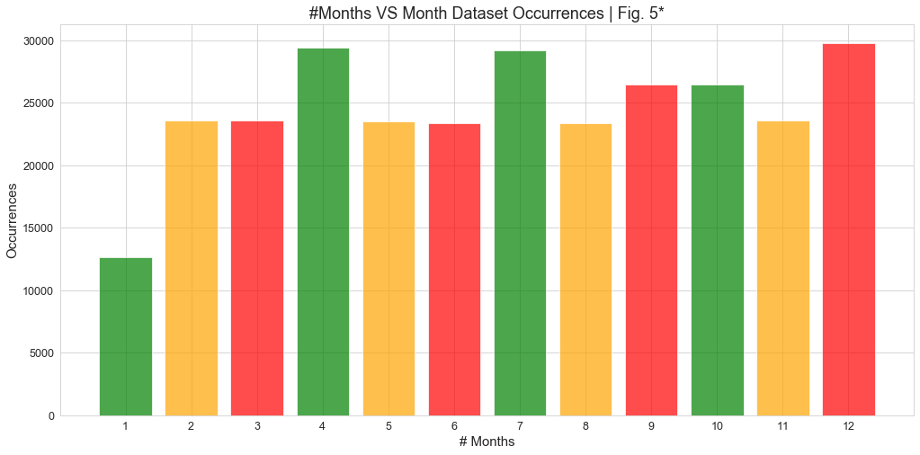

```python
fig, ax = plt.subplots(figsize=(17,8))

unique, counts = np.unique(df_eda['Month'], return_counts=True)
print("Months:", unique.tolist())
print("Counts:", counts.tolist())

ax.bar(unique, counts, color=['g', 'orange', 'r'], alpha=0.7)
ax.set_title("#Months VS Month Dataset Occurrences | Fig. 5*", fontsize=18)
ax.set_xticks(unique.tolist())
ax.set_ylabel("Occurrences", fontsize=15)
ax.set_xlabel("# Months", fontsize=15);
ax.tick_params(labelsize=12.5)

print("This is just to make sure that the rise on the 12th month is not caused by the abundance of the class, as they all values are pretty close")
```

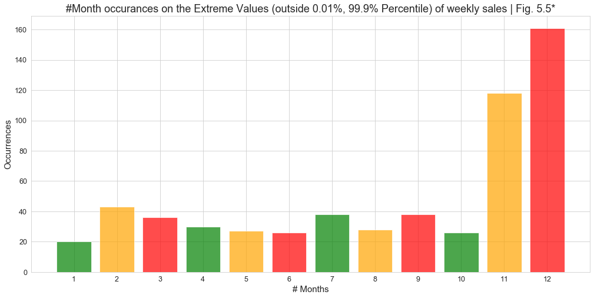

```python
fig, ax = plt.subplots(figsize=(17,8))

P003, P997= np.percentile(df_eda['Weekly_Sales'],[0.1,99.9])

P997 = df_eda['Weekly_Sales'] > P997
P003 = df_eda['Weekly_Sales'] < P003

unique, counts = np.unique(df_eda[P997 | P003]['Month'], return_counts=True)

ax.bar(unique, counts, color=['g', 'orange', 'r'], alpha=0.7)
ax.set_title("#Month occurances on the Extreme Values (outside 0.01%, 99.9% Percentile) of weekly sales | Fig. 5.5*", fontsize=18)
ax.set_xticks(unique.tolist())
ax.set_ylabel("Occurrences", fontsize=15)
ax.set_xlabel("# Months", fontsize=15);
ax.tick_params(labelsize=12.5)
```

#### Time Series by Day

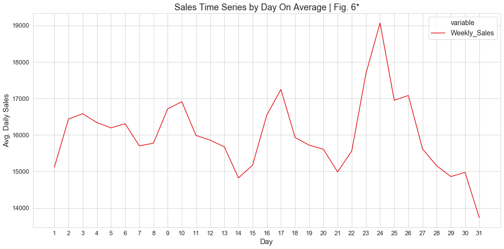

```python
time_series_sales = df_eda[['Day', 'Weekly_Sales']]
time_series_sales = time_series_sales.groupby(by='Day').mean()
time_series_sales['Day'] = time_series_sales.index

makeLineplot(data = time_series_sales, groubed_by_x='Day',
             title="Sales Time Series by Day On Average | Fig. 6*",
             fix_ticks_num=False, rotate=False, y_label="Avg. Daily Sales");
```

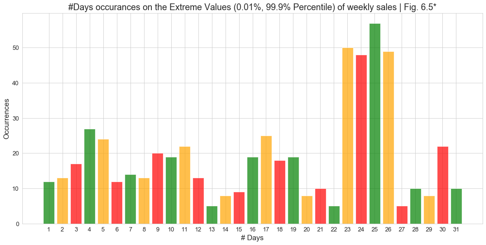

```python
fig, ax = plt.subplots(figsize=(17,8))

P003, P997= np.percentile(df_eda['Weekly_Sales'],[0.1,99.9])

P997 = df_eda['Weekly_Sales'] > P997
P003 = df_eda['Weekly_Sales'] < P003

unique, counts = np.unique(df_eda[P997 | P003]['Day'], return_counts=True)

ax.bar(unique, counts, color=['g', 'orange', 'r'], alpha=0.7)
ax.set_title("#Days occurances on the Extreme Values (0.01%, 99.9% Percentile) of weekly sales | Fig. 6.5*", fontsize=18)
ax.set_xticks(unique.tolist())
ax.set_ylabel("Occurrences", fontsize=15)
ax.set_xlabel("# Days", fontsize=15);
ax.tick_params(labelsize=12.5)
```

#### Again, Validate that rises are not caused by abundance of class

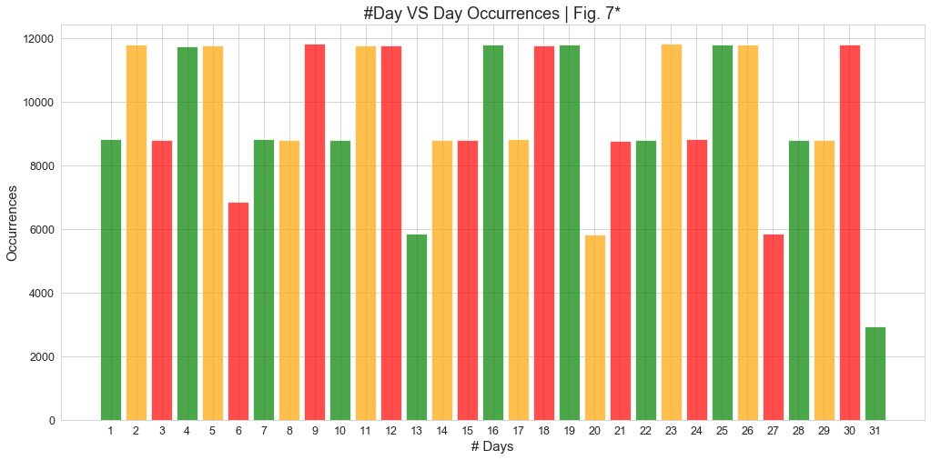

```python
fig, ax = plt.subplots(figsize=(17,8))

unique, counts = np.unique(df_eda['Day'], return_counts=True)

ax.bar(unique, counts, color=['g', 'orange', 'r'], alpha=0.7)
ax.set_title("#Day VS Day Occurrences | Fig. 7*", fontsize=18)
ax.set_xticks(unique.tolist())
ax.set_ylabel("Occurrences", fontsize=15)
ax.set_xlabel("# Days", fontsize=15);
ax.tick_params(labelsize=12.5)
```

#### Explaining the 23-24-25-26 High Sales Days

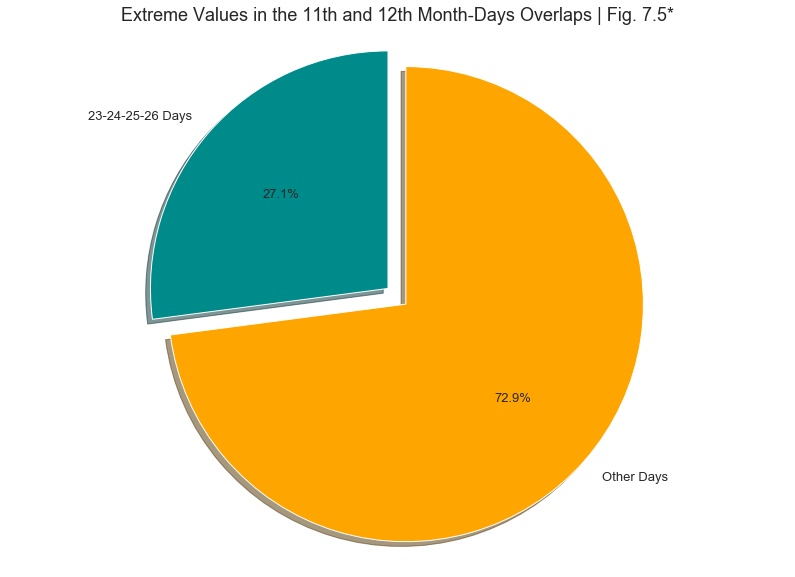

```python
high_sale_days = df_eda[(P997 | P003)
               & (
                   (df_eda['Day'] == 23) |
                   (df_eda['Day'] == 24) |
                   (df_eda['Day'] == 25) |
                   (df_eda['Day'] == 26))].index

high_sale_months = df_eda[(P997 | P003)
       & (
           (df_eda['Month'] == 12) |
           (df_eda['Month'] == 11))].index

counter_overlap = 0
for month_idx in high_sale_months:
    for day_idx in high_sale_days:
        if month_idx == day_idx:
            counter_overlap+=1

labels = ['23-24-25-26 Days', 'Other Days']
overlaps = [counter_overlap, df_eda[(P997 | P003)].shape[0] - counter_overlap]

fig, ax = plt.subplots(figsize=(14,10))

explode = (0.1, 0)
ax.pie(overlaps, explode=explode, labels=labels, autopct='%1.1f%%',
        shadow=True, startangle=90, colors=['darkcyan', 'orange'])

ax.axis('equal')
ax.set_title("Extreme Values in the 11th and 12th Month-Days Overlaps | Fig. 7.5*", fontsize=18);
```

#### Relate Time-changing variables in the dataset

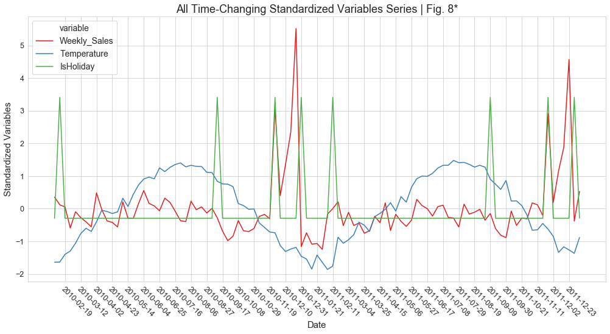

```python
time_series_sales = df_eda[['Date', 'Temperature', 'IsHoliday',  'Weekly_Sales']]
time_series_sales['avg_markdowns'] = df_eda[['MarkDown1', 'MarkDown2', 'MarkDown3',
                                             'MarkDown4', 'MarkDown5']].loc[:,:].mean(axis = 1)

time_series_sales = time_series_sales.groupby(by='Date').mean()

time_series_sales = pd.DataFrame(StandardScaler().fit_transform(time_series_sales.values),
                                 columns=time_series_sales.columns, index=time_series_sales.index)

time_series_sales['Date'] = time_series_sales.index

makeLineplot(data = time_series_sales, groubed_by_x='Date',
             title="All Time-Changing Standardized Variables Series | Fig. 8*",
             hue_order=['Weekly_Sales', 'Temperature', 'IsHoliday'], y_label="Standardized Variables");
```

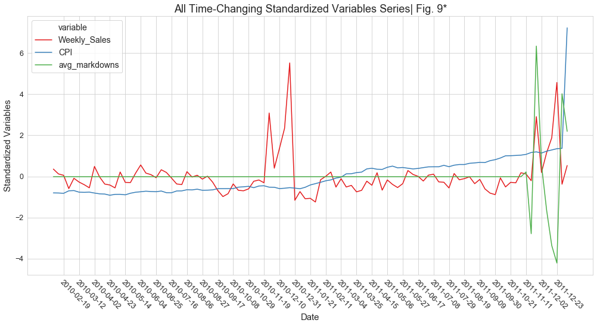

```python
time_series_sales = df_eda[[ 'CPI', 'Date', 'Weekly_Sales']]
time_series_sales['avg_markdowns'] = df_eda[['MarkDown1', 'MarkDown2', 'MarkDown3',
                                             'MarkDown4', 'MarkDown5']].loc[:,:].mean(axis = 1)

time_series_sales = time_series_sales.groupby(by='Date').mean()

time_series_sales = pd.DataFrame(StandardScaler().fit_transform(time_series_sales.values),
                                 columns=time_series_sales.columns, index=time_series_sales.index)

time_series_sales['Date'] = time_series_sales.index

makeLineplot(data = time_series_sales, groubed_by_x='Date',
             title="All Time-Changing Standardized Variables Series| Fig. 9*",
             hue_order=['Weekly_Sales', 'CPI', 'avg_markdowns'], y_label="Standardized Variables");
```

## Insights:

### Correlation Matrix

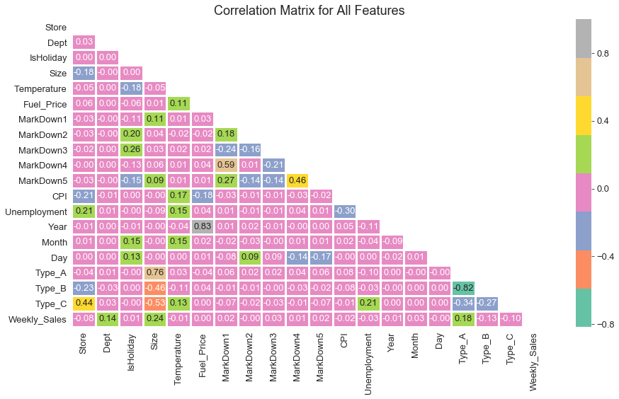

```python
fig, ax = plt.subplots(figsize=(15,8))

ax.axes.set_title("Correlation Matrix for All Features",fontsize=18)
ax.tick_params(labelsize=13)

corr = df_eda.corr()
mask = np.triu(corr)
sns.heatmap(corr, cmap= 'Set2', linewidths=2, ax=ax, annot=True, mask=mask, fmt='.2f');
```

## Insights:

### Feature Importance using LGBM Regressor & RF Regressor

Remember, we want the model to overfit telling us that it was able to learn the data very strongly and the features I have chosen were helping me a lot. Of course we should be more strict a bit with this and do some cross folds. But this is just to save development time as we have already analysed most variables strongly and this is an extra (An important) indicator that we check if it conforms with our analysis so far

```python
test_dates = X_test['Date']
train_dates = X_train['Date']
X_train = X_train.drop('Date', axis=1)
X_test = X_test.drop('Date', axis=1)
X_train.fillna(X_train.mean(), inplace=True)
X_test.fillna(X_train.mean(), inplace=True)
```

LGBM

```python
lgbm = LGBMRegressor(n_jobs=-1).fit(X_train, y_train)
lgbm.score(X_train, y_train)
```

```
0.9127833902860457
```

RF-Reg

```python
rf_reg = RandomForestRegressor(n_jobs=-1).fit(X_train, y_train)
rf_reg.score(X_train, y_train)
```

```
0.9961698584013244
```

```python
coef_lgbm = pd.DataFrame(lgbm.feature_importances_, columns=['Importance'])
coef_lgbm['Feature'] = df_eda.drop('Date', inplace=False, axis=1).columns[:-1]
coef_lgbm["clf"] = 'LGBM'
coef_lgbm['Importance'] = MinMaxScaler().fit_transform(coef_lgbm['Importance'].values.reshape(-1, 1))


coef_rf_reg = pd.DataFrame(rf_reg.feature_importances_, columns=['Importance'])
coef_rf_reg['Feature'] = df_eda.drop('Date', inplace=False, axis=1).columns[:-1]
coef_rf_reg["clf"] = 'RF_REG'
coef_rf_reg['Importance'] = MinMaxScaler().fit_transform(coef_rf_reg['Importance'].values.reshape(-1, 1))


feature_importances = coef_lgbm.append(coef_rf_reg)
feature_importances['Importance'] = MinMaxScaler().fit_transform(feature_importances['Importance'].values.reshape(-1, 1))
feature_importances.head()
```

|  | Importance | Feature | clf |
| --- | --- | --- | --- |
| 0 | 0.222222 | Store | LGBM |
| 1 | 1.000000 | Dept | LGBM |
| 2 | 0.015326 | IsHoliday | LGBM |
| 3 | 0.221584 | Size | LGBM |
| 4 | 0.035760 | Temperature | LGBM |

### Note:

Figure has been zoomed from 1.0 to 0.35 as **Feature Dept is 1.0** and is really high compared to others. (No other features data point has been lost)

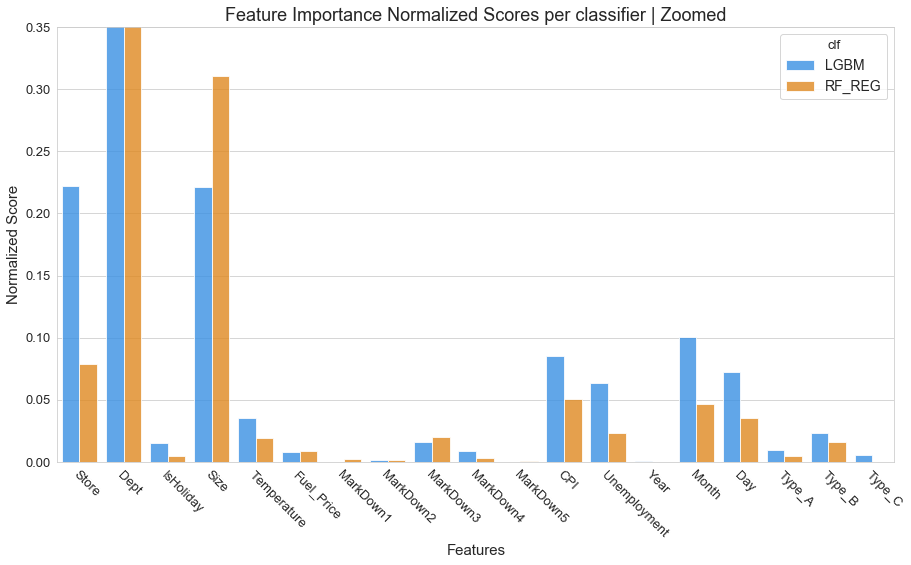

```python
fig, ax = plt.subplots(figsize=(15,8))
ax = sns.barplot(x='Feature', y="Importance", hue="clf", data=feature_importances, palette=['dodgerblue', 'darkorange'], alpha=0.8)

ax.axes.set_title("Feature Importance Normalized Scores per classifier | Zoomed",fontsize=18)
ax.set_xlabel("Features",fontsize=15)
ax.set_ylabel("Normalized Score",fontsize=15)
ax.tick_params(labelsize=13)

ax.set(ylim=(0, 0.35))
plt.setp( ax.xaxis.get_majorticklabels(), rotation=-45, ha="left", rotation_mode="anchor");
```

# Features Choice

Based on corr. matrix, LGBM feature importnace, RF Regressor Feature importance.

- **Store:** Strong contribution to target in Clfs Feature importances
- **Dept:** Strong contribution to target in all feature selection analysis
- **Size:** Strong contribution to target in all feature selection analysis
- **Markdown 1 and 3:** Missing the first 60% of data which might mislead the model in thinking that 2012 always have more sales when markdowns appear, but we will add Markdown 1 as it appears to be strongly correlated with other markdowns and can suffice, and MarkDown 3 as it shows a fairly good enough feature importance
- **All types:** They have shown a strong +ve/-ve correlation in the correlation matrix
- **CPI:** Has a fair feature importance but also appears to be a good substitute for many features we have gotten rid of in the correlation matrix
- **Month and Day:** Both have shown a good variance in Time Series plots, and a good feature importance

```python
X_train_feat = X_train[['Store', 'Dept', 'MarkDown1', 'MarkDown3', 'CPI', 'Size',
                            'Type_A', 'Type_B', 'Type_C', 'Month', 'Day']]

X_test_feat = X_test[['Store', 'Dept', 'MarkDown1', 'MarkDown3', 'CPI', 'Size',
                            'Type_A', 'Type_B', 'Type_C', 'Month', 'Day']]


scaler = StandardScaler().fit(X_train_feat.values)
X_train_feat_sc =  pd.DataFrame(scaler.transform(X_train_feat.values),
                              columns=X_train_feat.columns,
                              index=X_train_feat.index.tolist()).fillna(X_train_feat.mean())

X_test_feat_sc = pd.DataFrame(scaler.transform(X_test_feat.values),
                            columns=X_test_feat.columns,
                            index=X_test_feat.index.tolist()).fillna(X_train_feat.mean())
```

```python
df_eda_featured = pd.concat([X_train[['Store', 'Dept', 'MarkDown1', 'MarkDown3', 'CPI', 'Size',
                            'Type_A', 'Type_B', 'Type_C', 'Month', 'Day']],
                             y_train], axis=1)
df_eda_featured.head()
```

|  | Store | Dept | MarkDown1 | MarkDown3 | CPI | Size | Type_A | Type_B | Type_C | Month | Day | Weekly_Sales |
| --- | --- | --- | --- | --- | --- | --- | --- | --- | --- | --- | --- | --- |
| 0 | 1 | 1 | 4585.925206 | 7933.27552 | 211.096358 | 151315 | 1 | 0 | 0 | 2 | 5 | 24924.50 |
| 1 | 1 | 2 | 4585.925206 | 7933.27552 | 211.096358 | 151315 | 1 | 0 | 0 | 2 | 5 | 50605.27 |
| 2 | 1 | 3 | 4585.925206 | 7933.27552 | 211.096358 | 151315 | 1 | 0 | 0 | 2 | 5 | 13740.12 |
| 3 | 1 | 4 | 4585.925206 | 7933.27552 | 211.096358 | 151315 | 1 | 0 | 0 | 2 | 5 | 39954.04 |
| 4 | 1 | 5 | 4585.925206 | 7933.27552 | 211.096358 | 151315 | 1 | 0 | 0 | 2 | 5 | 32229.38 |

# More EDA on Chosen Features

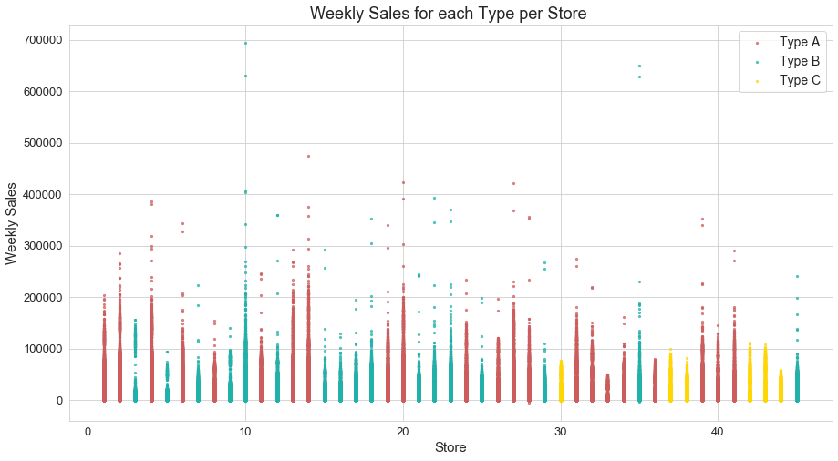

```python
fig, ax = plt.subplots(figsize=(15,8))

ax.scatter(df_eda[df_eda["Type_A"] == 1]['Store'],
            df_eda[df_eda["Type_A"] == 1]['Weekly_Sales'], label='Type A',
            s=5, c='indianred',
           alpha=0.7)

ax.scatter(df_eda[df_eda["Type_B"] == 1]['Store'],
            df_eda[df_eda["Type_B"] == 1]['Weekly_Sales'], label='Type B',
            s=5, c='lightseagreen',
           alpha=0.7)

ax.scatter(df_eda[df_eda["Type_C"] == 1]['Store'],
            df_eda[df_eda["Type_C"] == 1]['Weekly_Sales'], label='Type C',
            s=5, c='gold',
           alpha=0.7)

ax.tick_params(labelsize=13)
ax.set_title("Weekly Sales for each Type per Store ", fontsize=18);
ax.set_xlabel('Store', fontsize=15)
ax.set_ylabel('Weekly Sales', fontsize=15)

plt.legend();
```

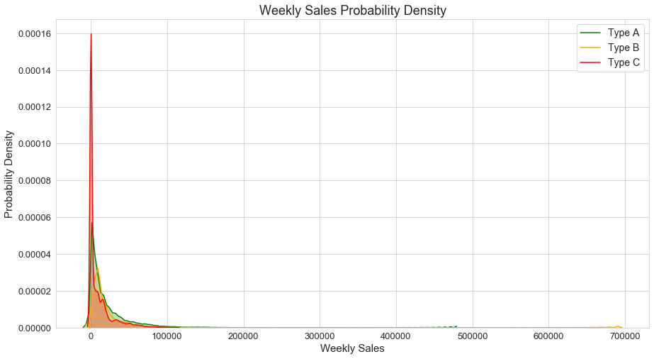

```python
fig, ax = plt.subplots(figsize=(15,8))

sns.kdeplot(df_eda[df_eda['Type_A'] == 1]['Weekly_Sales'], color='g', shade=True, Label='Type A')
sns.kdeplot(df_eda[df_eda['Type_B'] == 1]['Weekly_Sales'], color='orange', shade=True, Label='Type B')
sns.kdeplot(df_eda[df_eda['Type_C'] == 1]['Weekly_Sales'], color='r', shade=True, Label='Type C')

# plt.xlim(-100, 600);

ax.axes.set_title("Weekly Sales Probability Density",fontsize=18)
ax.set_xlabel("Weekly Sales",fontsize=15)
ax.set_ylabel("Probability Density",fontsize=15)
ax.tick_params(labelsize=13)
```

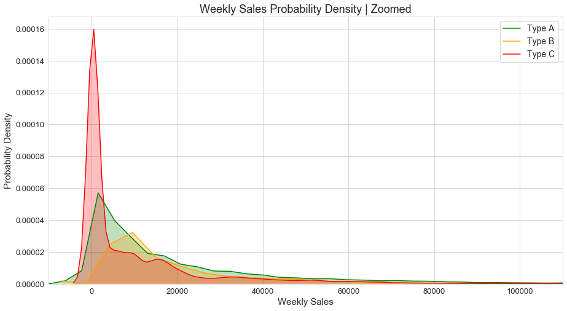

```python
fig, ax = plt.subplots(figsize=(15,8))

sns.kdeplot(df_eda[df_eda['Type_A'] == 1]['Weekly_Sales'], color='g', shade=True, Label='Type A')
sns.kdeplot(df_eda[df_eda['Type_B'] == 1]['Weekly_Sales'], color='orange', shade=True, Label='Type B')
sns.kdeplot(df_eda[df_eda['Type_C'] == 1]['Weekly_Sales'], color='r', shade=True, Label='Type C')

plt.xlim(-10000, 110000);

ax.axes.set_title("Weekly Sales Probability Density | Zoomed",fontsize=18)
ax.set_xlabel("Weekly Sales",fontsize=15)
ax.set_ylabel("Probability Density",fontsize=15)
ax.tick_params(labelsize=13)
```

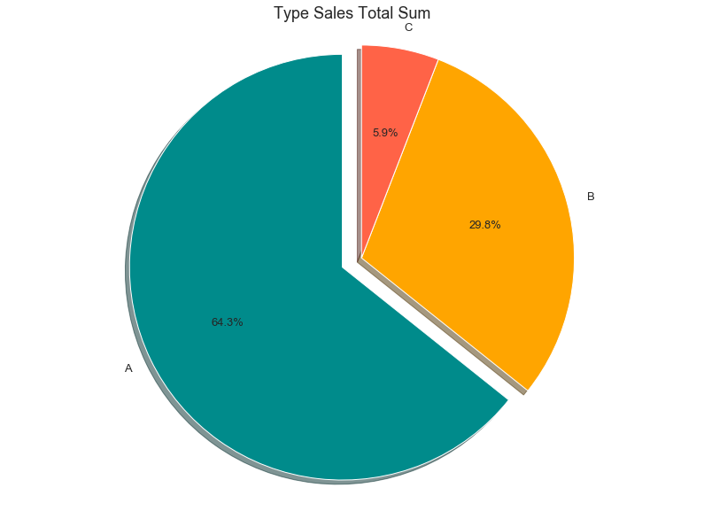

```python
a_sales = df_eda[df_eda['Type_A'] == 1]['Weekly_Sales'].sum()
b_sales = df_eda[df_eda['Type_B'] == 1]['Weekly_Sales'].sum()
c_sales = df_eda[df_eda['Type_C'] == 1]['Weekly_Sales'].sum()

types = ['A', 'B', 'C']
all_sales = [a_sales, b_sales, c_sales]

fig, ax = plt.subplots(figsize=(14,10))


explode = (0.1, 0, 0)
ax.pie(all_sales, explode=explode, labels=types, autopct='%1.1f%%',
        shadow=True, startangle=90, colors=['darkcyan', 'orange', 'tomato'])

ax.axis('equal')

ax.set_title("Type Sales Total Sum", fontsize=18);
```

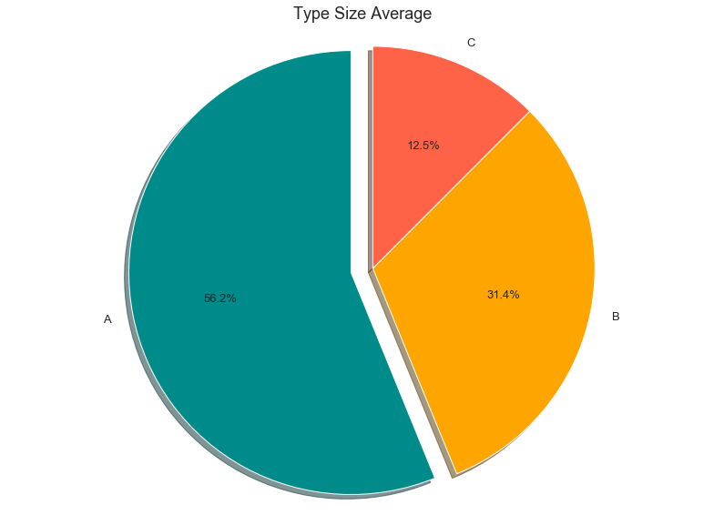

```python
a_size = df_eda[df_eda['Type_A'] == 1]['Size'].mean()
b_size = df_eda[df_eda['Type_B'] == 1]['Size'].mean()
c_size = df_eda[df_eda['Type_C'] == 1]['Size'].mean()

types = ['A', 'B', 'C']
all_sales = [a_size, b_size, c_size]

fig, ax = plt.subplots(figsize=(14,10))


explode = (0.1, 0, 0)
ax.pie(all_sales, explode=explode, labels=types, autopct='%1.1f%%',
        shadow=True, startangle=90, colors=['darkcyan', 'orange', 'tomato'])

ax.axis('equal')

ax.set_title("Type Size Average", fontsize=18);
```

### Insight:

We can clearly tell from these three figures that

- Type A holds most of the high sales and the highest profitable one but not huge sales (outliers)
- Type B focuses on the very outliers as shown the guassian density function
- Type C Definitely holds the lowest as well as most of its distribution is on the least values
- Size is strongly correlated with weekly sales and type

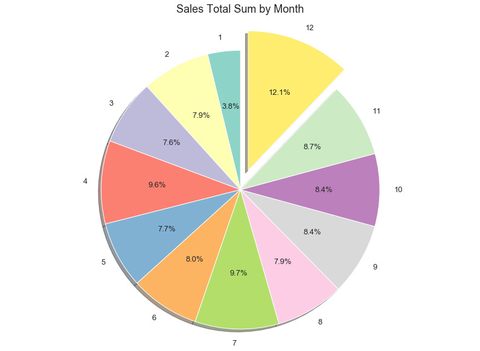

```python
month_sales_sum = df_eda[['Month', 'Weekly_Sales']].groupby(by='Month').sum()

fig, ax = plt.subplots(figsize=(14,10))
explode = [0]*12
explode[11] = 0.15

cmap = plt.get_cmap("Set3")
cmap_colors = cmap(np.arange(12))

ax.pie(month_sales_sum['Weekly_Sales'].tolist(), labels=month_sales_sum.index.tolist(), autopct='%1.1f%%',
        shadow=True, startangle=90, colors=cmap_colors, explode=explode)
ax.axis('equal')
ax.set_title("Sales Total Sum by Month", fontsize=18);
```

### Normalize data before PCA and UMAP Reductions

### Notes for PCA and UMAP

- Remove Type category as it is not meaningful when calculating eigenvalues and eigenvectors for 0, 1 values with PCA
- I will use UMAP Supervised dimensionality reduction technique with an L2 target metric for regression analysis
- I have used StandardScaler (Z-Score) scalar so that a feature doesn't over rule others in calculating eigenvalues; As well as not losing outliers when using the Z-Score. This was done in previous stages of this notbook

```python
pca = PCA(n_components=2)
principalComponents = pca.fit_transform(
X_train_feat_sc.drop(inplace = False, columns=['Type_A', 'Type_B', 'Type_C']))
principalComponents = pd.DataFrame(principalComponents)
```

# —————————

**Moved To Different Notebook/Kernel by variable passing due to time-consuming operation**

```python
# export DFs and Series

# %store X_train_feat_sc
# %store y_train
# %store X_test_feat_sc
```

```python
# import umap
# umap = umap.UMAP(verbose=False, n_components=2, target_metric='l2')
# embedding = umap.fit_transform(X=X_train_feat_sc, y=y_train)
# embedding = pd.DataFrame(embedding)
```

```python
# import the results

# %store -r embedding_train
# %store -r embedding_test
```

**Moved To Different Notebook/Kernel by variable passing due to time-consuming operation**

# —————————

```python
Q1 = y_train.quantile(0.25)
median = y_train.quantile(0.5)
Q3 = y_train.quantile(0.75)

# We can use the 1.5 * IQR but this is highly skewed dataset and we will have to change the 1.5
outlier = Q3 + 1.5 * (Q3 - Q1)
extreme = Q3 + 3.0 * (Q3 - Q1)


color_ranges = []
sizes = []
for point in y_train:
    if(point <= Q1):
        color_ranges.append('red')
        sizes.append(20)
    elif(point <= median):
        color_ranges.append('cyan')
        sizes.append(50)

    elif(point <= Q3):
        color_ranges.append('orange')
        sizes.append(80)

    elif(point <= outlier):
        color_ranges.append('pink')
        sizes.append(150)

    elif(point <= extreme):
        color_ranges.append('mediumslateblue')
        sizes.append(230)

    elif(point > extreme):
        color_ranges.append('green')
        sizes.append(350)

    else:
        print('point missed')

legend_elements = [Line2D([0], [0], marker='o', color='w', label='WS < Q1',
                          markerfacecolor='red', markersize=15),

                   Line2D([0], [0], marker='o', color='w', label='Q1 < WS < Median',
                          markerfacecolor='cyan', markersize=15),

                   Line2D([0], [0], marker='o', color='w', label='Median < WS < Q3',
                          markerfacecolor='orange', markersize=15),

                  Line2D([0], [0], marker='o', color='w', label='Q3 < WS < Q Outlier',
                          markerfacecolor='pink', markersize=15),

                  Line2D([0], [0], marker='o', color='w', label='Q Outlier < WS < Q Extreme',
                          markerfacecolor='mediumslateblue', markersize=15),

                  Line2D([0], [0], marker='o', color='w', label='WS > Q Extreme',
                          markerfacecolor='green', markersize=15)]
```

### PCA Visualization

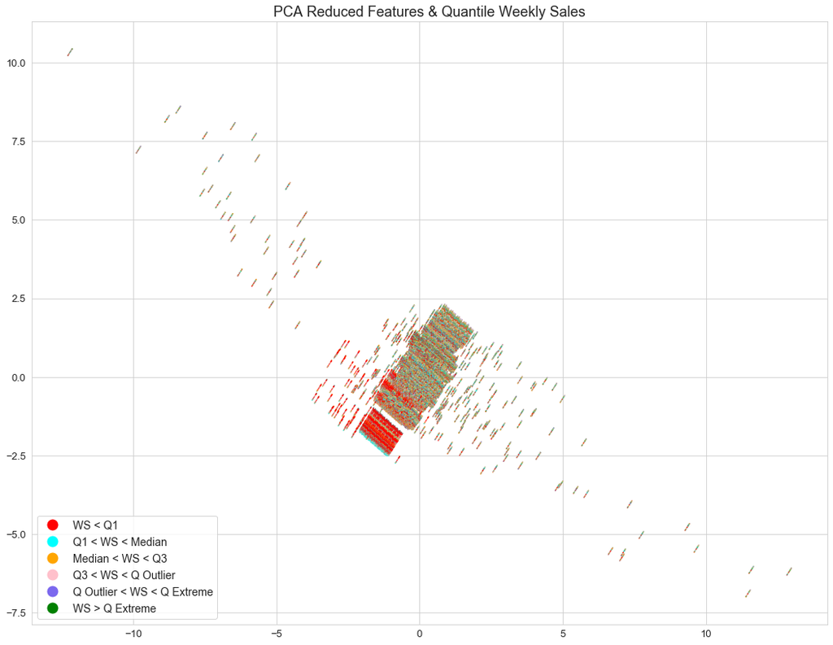

```python
fig, ax = plt.subplots(figsize=(18,14))

ax.legend(handles=legend_elements, loc='lower left')
ax.axes.set_title('PCA Reduced Features & Quantile Weekly Sales',fontsize=18)
ax.tick_params(labelsize=13)

ax.scatter(principalComponents[0], principalComponents[1], c=color_ranges, s=0.3, alpha=0.3);
```

### UMAP Visualization

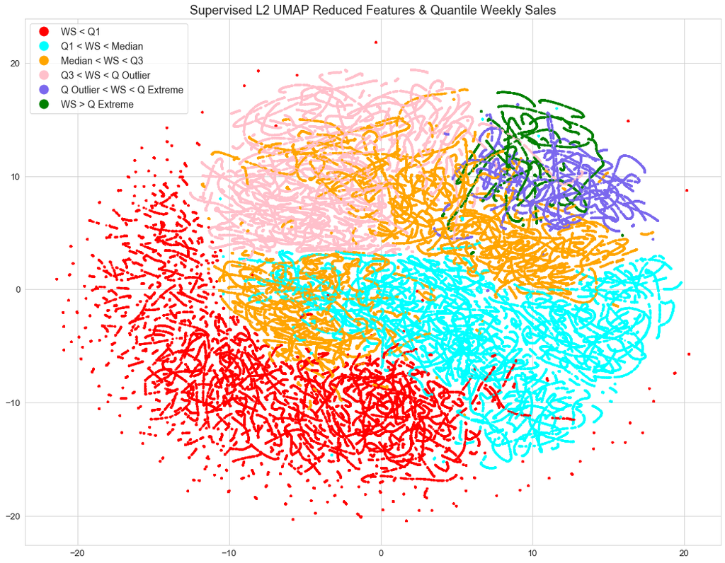

```python
fig, ax = plt.subplots(figsize=(18,14))

ax.legend(handles=legend_elements, loc='upper left')
ax.axes.set_title('Supervised L2 UMAP Reduced Features & Quantile Weekly Sales',fontsize=18)
ax.tick_params(labelsize=13)

ax.scatter(embedding_train[0], embedding_train[1], c=color_ranges, s=5, alpha=0.7);
```

### Insights

- UMAP: Very smooth and nice seperation between the distributional quantile classes of weekly sales, but keep in mind that this is a supervised technique, but remember that the reduction of test data will try to transform each value to it's closest number as illustrated, then a regression ML model can be used after
- PCA there're some very weak and not clear clusters in the data and it doesn't look promising

# Modeling

### Models

1. **DummyRegressor** Our Base-Line
1. **KNeighborsRegressor** It might be very suitable to work with quantile clusters produced by UMAP reduced features
1. **LGBMRegressor** There are many outliers in the dataset which will surely be falsely predicted by the classifier. A gradient boosting algorithm that gives a higher weight for false predictions is a good one to go with as the model might underfit the whole dataset due to abundance of outliers and extremes.
1. **RandomForestRegressor** Bagging can solve any overfitting that a model on this dataset might fall into due to the skewness of the dataset.

**Basically**: LGBM is to solve underfitting which is not strongly likely to happen as the model might overfit and the skewed partition and predicts everything to be a low value disregarding that there are extremes sometimes. Hence RFG is to solve this issue of overfitting due to bootstrapping and aggregation of multiple DT's (Decision Trees are going to be our weak learners).

### Quality Metrics

1. **MAE (Mean Absolute Error)** We have a highly right-skewed dataset with too many extremes and outliers. We need a metric that is not very sensitive to outliers
1. **R-Squared/Coefficient of Determination** To know how much of the response variable's variance is explained by the regression model.
1. **Time-series plot of predictions vs truths** To account for any wrong patterns or flaws that the model might be following
1. **Residual Plot** To account for the possible misleading explanation of R-Squared value caused by continuous response variable prediction over/under-estimates, bias, or residual pattern

```python
def tuner_trainer(model, X_train, y_train, params):
    pipeline = Pipeline([
            ('scale', StandardScaler()),
            ('regre', model)])

    tscv = TimeSeriesSplit(n_splits = 5)
    grid = GridSearchCV(pipeline, param_grid = params, cv=tscv,
                        n_jobs=-1, refit=True, scoring='neg_mean_absolute_error', verbose=True)
    grid.fit(X_train, y_train)


    X_train_sc = pd.DataFrame(StandardScaler().fit_transform(X_train.values),
                              columns=X_train.columns,
                              index=X_train.index.tolist())
    model = grid.best_estimator_.fit(X_train_sc, y_train)
    return {
        "model": model,
        "best_params": grid.best_params_,
        "best_score": grid.best_score_
    }

def evaluate(indicies, y_train, y_train_preds, y_test, y_test_preds, res_plot=True, time_plot=True):

    if (time_plot):
        data = pd.DataFrame({
            "y_test": y_test,
            "y_test_preds": y_test_preds,
            "Date": indicies
        }).set_index('Date').groupby('Date').mean()

        data = pd.DataFrame(StandardScaler().fit_transform(data.values),
                                         columns=data.columns, index=data.index)

        data['Date'] = data.index.tolist()


        makeLineplot(data = data, groubed_by_x='Date',
                     title="Weekly Sales Truth vs Predictions",
                     hue_order=['y_test', 'y_test_preds'], fix_ticks_num=False);
    if(res_plot):
        fig, ax = plt.subplots(figsize=(17, 6))
        residuals = np.asarray(y_test - y_test_preds)
        residuals = StandardScaler().fit_transform(residuals.reshape(-1, 1))
        residuals = np.squeeze(residuals)
        y_test_scaled = StandardScaler().fit_transform(y_test_preds.reshape(-1, 1).tolist())
        y_test_scaled = np.squeeze(y_test_scaled)
        sns.residplot(y_test_scaled, residuals, color=(1, 0, 0, 0.3))

    return {
        "mae_train": mean_absolute_error(y_train_preds, y_train),
        "r2_train": r2_score(y_train_preds, y_train),
        "mae_test": mean_absolute_error(y_test, y_test_preds),
        "r2_test": r2_score(y_test, y_test_preds)
    }
```

### Hyperparameters

```python
knr = KNeighborsRegressor()
knr_params = {
    'regre__n_neighbors': [int(np.sqrt(X_train_feat_sc.shape[0])/5),
                           int(np.sqrt(X_train_feat_sc.shape[0])/10),
                           int(np.sqrt(X_train_feat_sc.shape[0])/15)], # Try not to put even numbers
    'regre__weights': ['uniform', 'distance'],
    'regre__n_jobs': [-1],
    'regre__algorithm': ['auto']}


lgbm = LGBMRegressor()
lgbm_params = {'regre__n_estimators': [900, 1800, 2700, 3500],
               'regre__max_depth':  [3, 6, 12, -1],
               'regre__subsample': [0.6, 1.0],
               'regre__colsample_bytree': [0.6, 1.0],
               'regre__n_jobs': [-1]}

rf_reg = RandomForestRegressor()
rf_reg_params = {"regre__max_depth": [3, 6, 12, None],
                 "regre__n_estimators": [100, 300, 500],
                 'regre__n_jobs': [-1]}


base_line = DummyRegressor(strategy='mean')
indicies = test_dates
```

### Base-Line Regressor

```python
base_line_grid = tuner_trainer(base_line, X_train_feat, y_train, {});
```

```
{'mae_train': 15236.547658593352,
 'r2_train': -1.9683491459625592e+30,
 'mae_test': 15148.386510144517,
 'r2_test': -0.0003705084759870747}
```

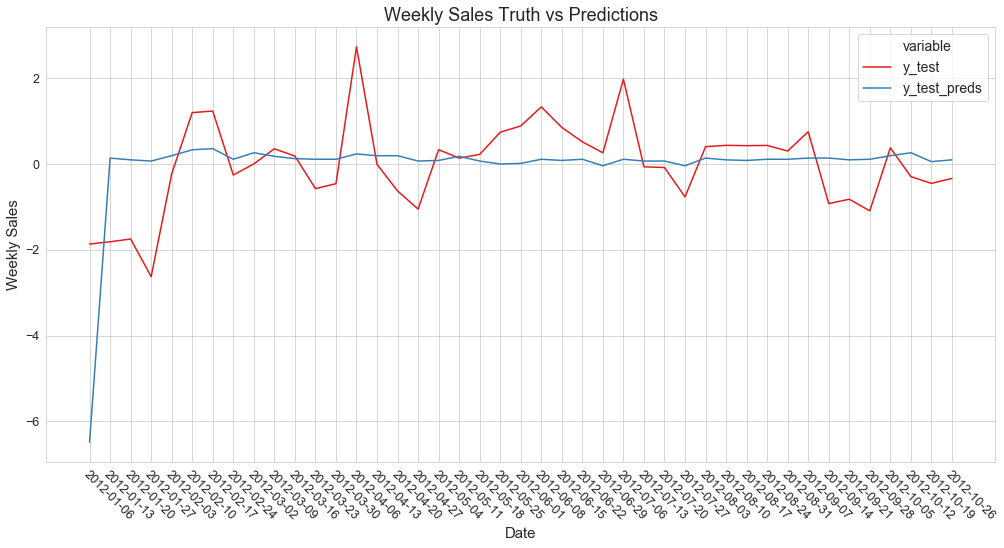

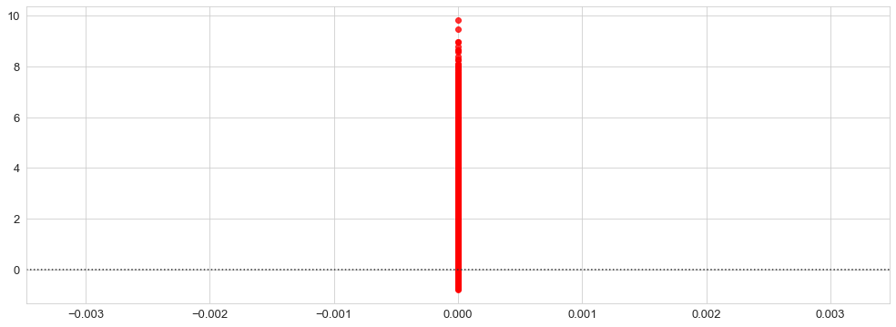

```python
y_train_preds = base_line_grid["model"].predict(X_train_feat_sc)
y_test_preds = base_line_grid["model"].predict(X_test_feat_sc)

base_line_grid_res = evaluate(indicies, y_train, y_train_preds, y_test, y_test_preds)
base_line_grid_res
```

### K-Neighbors Regressor

```python
knr_grid = tuner_trainer(knr, X_train_feat, y_train, knr_params);
knr_grid["best_params"]
```

```
{'regre__algorithm': 'auto',
 'regre__n_jobs': -1,
 'regre__n_neighbors': 36,
 'regre__weights': 'distance'}
```

```
{'mae_train': 0.0,
 'r2_train': 1.0,
 'mae_test': 12424.05106240003,
 'r2_test': 0.24912852307482636}
```

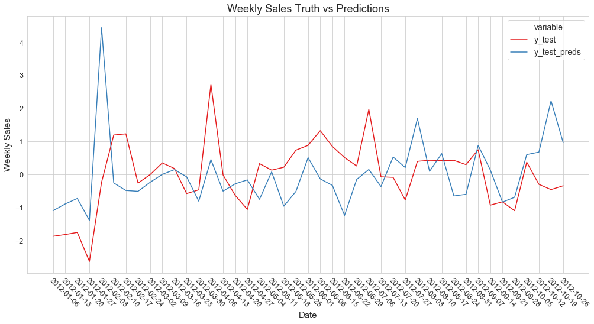

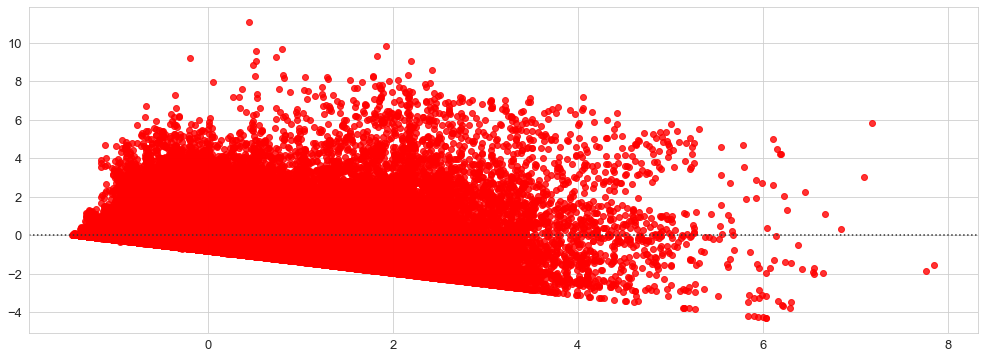

```python
y_train_preds = knr_grid["model"].predict(X_train_feat_sc)
y_test_preds = knr_grid["model"].predict(X_test_feat_sc)

knr_grid_res = evaluate(indicies, y_train, y_train_preds, y_test, y_test_preds)
knr_grid_res
```

### LGBM Regressor

```python
lgbm_grid = tuner_trainer(lgbm, X_train_feat, y_train, lgbm_params);
lgbm_grid["best_params"]
```

```
{'regre__colsample_bytree': 1.0,
 'regre__max_depth': -1,
 'regre__n_estimators': 3500,
 'regre__n_jobs': -1,
 'regre__subsample': 1.0}
```

```
{'mae_train': 1324.7258571023071,
 'r2_train': 0.9885291442631802,
 'mae_test': 2295.435398350228,
 'r2_test': 0.9642456665535191}
```

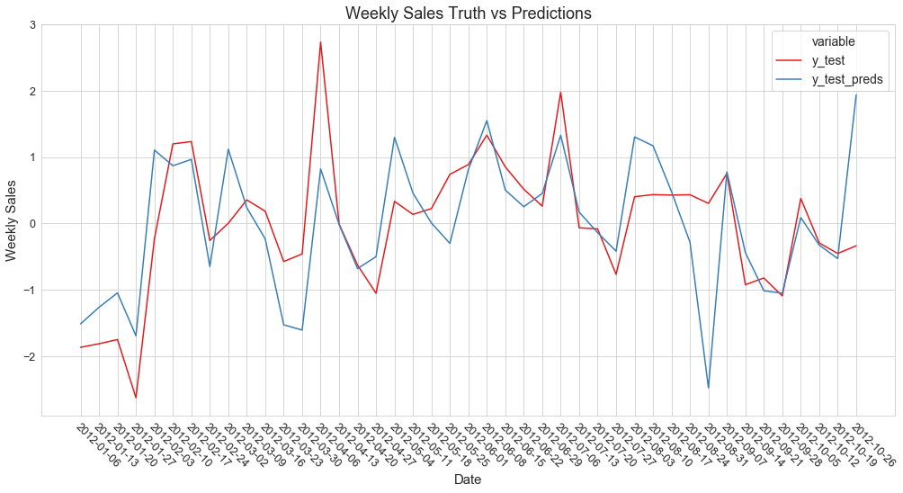

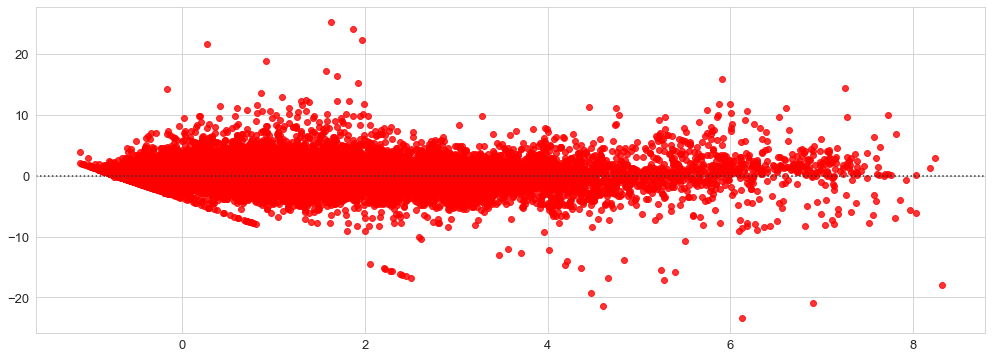

```python
y_train_preds = lgbm_grid["model"].predict(X_train_feat_sc)
y_test_preds = lgbm_grid["model"].predict(X_test_feat_sc)

lgbm_grid_res = evaluate(indicies, y_train, y_train_preds, y_test, y_test_preds)
lgbm_grid_res
```

### Random Forest Regressor

```python
rf_reg_grid = tuner_trainer(rf_reg, X_train_feat, y_train, rf_reg_params);
rf_reg_grid["best_params"]
```

```
{'regre__max_depth': None, 'regre__n_estimators': 300, 'regre__n_jobs': -1}
```

```
{'mae_train': 507.49125045572265,
 'r2_train': 0.9964421681559679,
 'mae_test': 2175.0319255681798,
 'r2_test': 0.9513854722124724}
```

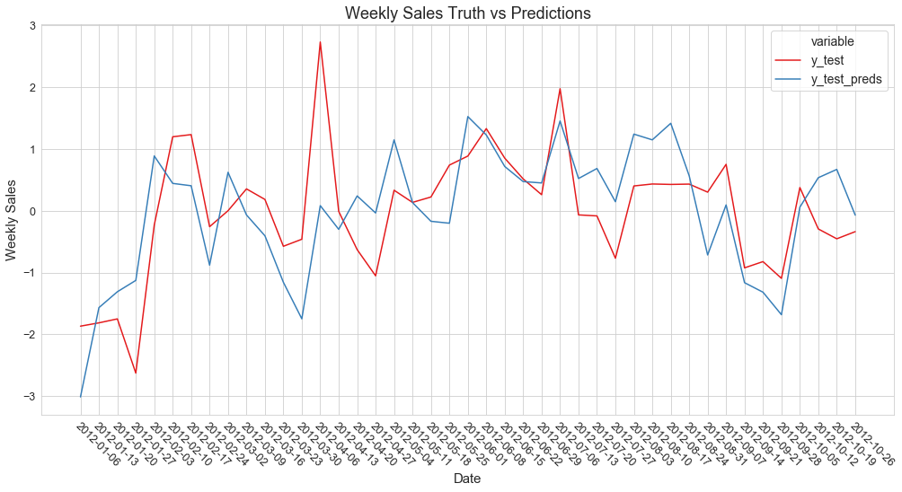

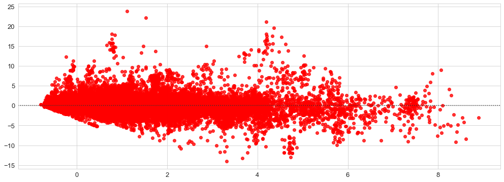

```python
y_train_preds = rf_reg_grid["model"].predict(X_train_feat_sc)
y_test_preds = rf_reg_grid["model"].predict(X_test_feat_sc)

rf_reg_grid_res = evaluate(indicies, y_train, y_train_preds, y_test, y_test_preds)
rf_reg_grid_res
```